# More R

```r
pacman::p_load(tidyverse)
```

# Homework

```r
x <- c(0,3.7,0,3.7,3.9,3.8,3.8,3.8,3.8,3.7,3.8)
stem(x)
```

```
  The decimal point is at the |

  0 | 00
  1 |
  2 |
  3 | 777888889
```

# Demo with more data sets

## Fatal Police Shootings

```r
load("fatal_police_shootings.rda")
ls()
```

```
[1] "fatal_police_shootings" "uniqdashc"              "wideScreen"
[4] "x"
```

```r
str(fatal_police_shootings)
```

```
'data.frame':   6421 obs. of  12 variables:
 $ date                   : chr  "2015-01-02" "2015-01-02" "2015-01-03" "2015-01-04" ...
 $ manner_of_death        : chr  "shot" "shot" "shot and Tasered" "shot" ...
 $ armed                  : chr  "gun" "gun" "unarmed" "toy weapon" ...
 $ age                    : int  53 47 23 32 39 18 22 35 34 47 ...
 $ gender                 : chr  "M" "M" "M" "M" ...
 $ race                   : chr  "A" "W" "H" "W" ...
 $ city                   : chr  "Shelton" "Aloha" "Wichita" "San Francisco" ...
 $ state                  : chr  "WA" "OR" "KS" "CA" ...
 $ signs_of_mental_illness: chr  "True" "False" "False" "True" ...
 $ threat_level           : chr  "attack" "attack" "other" "attack" ...
 $ flee                   : chr  "Not fleeing" "Not fleeing" "Not fleeing" "Not fleeing" ...
 $ body_camera            : chr  "False" "False" "False" "False" ...
```

```r
df <- fatal_police_shootings
df$date <- ymd(df$date)
str(df)
```

```
'data.frame':   6421 obs. of  12 variables:
 $ date                   : Date, format: "2015-01-02" "2015-01-02" ...
 $ manner_of_death        : chr  "shot" "shot" "shot and Tasered" "shot" ...
 $ armed                  : chr  "gun" "gun" "unarmed" "toy weapon" ...
 $ age                    : int  53 47 23 32 39 18 22 35 34 47 ...
 $ gender                 : chr  "M" "M" "M" "M" ...
 $ race                   : chr  "A" "W" "H" "W" ...
 $ city                   : chr  "Shelton" "Aloha" "Wichita" "San Francisco" ...
 $ state                  : chr  "WA" "OR" "KS" "CA" ...
 $ signs_of_mental_illness: chr  "True" "False" "False" "True" ...
 $ threat_level           : chr  "attack" "attack" "other" "attack" ...
 $ flee                   : chr  "Not fleeing" "Not fleeing" "Not fleeing" "Not fleeing" ...
 $ body_camera            : chr  "False" "False" "False" "False" ...
```

```r
summary(df$date)
```

```
        Min.      1st Qu.       Median         Mean      3rd Qu.         Max.
"2015-01-02" "2016-08-16" "2018-03-27" "2018-04-02" "2019-11-29" "2021-07-04"
```

```r
# stem(df$date)
stem(as.integer(df$date))
```

```
  The decimal point is 2 digit(s) to the right of the |

  164 | 44444444444444444444455555555555555555555555566666666666666666666666+73
  165 | 00000000000000000000000000111111111111111111111111111111111112222222+187
  166 | 00000000000000000000001111111111111111111112222222222222222222222222+206
  167 | 00000000000000000000000000000001111111111111111111122222222222222222+194
  168 | 00000000000000000000111111111111111111111112222222222222222222222222+199
  169 | 00000000000000000000000011111111111111111111111112222222222222222222+181
  170 | 00000000000000001111111111111111111111111111112222222222222222222222+172
  171 | 00000000000000000000000111111111111111111111111111122222222222222222+185
  172 | 00000000000000000000000000000000011111111111111111111111111111111111+186
  173 | 00000000000000000000000000000111111111111111111111112222222222222222+198
  174 | 00000000000000000000000000011111111111111111111111111222222222222222+186
  175 | 00000000000000000001111111111111111111111222222222222222222222222222+202
  176 | 00000000000000000000000000000000000000001111111111111111111111111111+228
  177 | 00000000000000000000000000000011111111111111111111111112222222222222+169
  178 | 00000000000000000000111111111111111111111111122222222222222222222222+155
  179 | 00000000000000000000000000000000000001111111111111111111111111111111+197
  180 | 00000000000000000000000000000011111111111111112222222222222222222222+185
  181 | 00000000000000000001111111111111111111111111111111111222222222222222+185
  182 | 00000000000000000000000000000111111111111111111111111111222222222222+213
  183 | 00000000000000000000000111111111111111111111111122222222222222222222+207
  184 | 00000000000000000000000000011111111111111111111111111111111111111111+194
  185 | 00000000000000000000001111111111111111111111222222222222222222222233+192
  186 | 00000000000000000000000000011111111111111111111111111111111222222222+188
  187 | 00000000000000000000000000001111111111111111112222222222222222222222+169
  188 | 00000000000000000000000000000000000111111111111111
```

```r
str(df)
```

```
'data.frame':   6421 obs. of  12 variables:
 $ date                   : Date, format: "2015-01-02" "2015-01-02" ...
 $ manner_of_death        : chr  "shot" "shot" "shot and Tasered" "shot" ...
 $ armed                  : chr  "gun" "gun" "unarmed" "toy weapon" ...
 $ age                    : int  53 47 23 32 39 18 22 35 34 47 ...
 $ gender                 : chr  "M" "M" "M" "M" ...
 $ race                   : chr  "A" "W" "H" "W" ...
 $ city                   : chr  "Shelton" "Aloha" "Wichita" "San Francisco" ...
 $ state                  : chr  "WA" "OR" "KS" "CA" ...
 $ signs_of_mental_illness: chr  "True" "False" "False" "True" ...
 $ threat_level           : chr  "attack" "attack" "other" "attack" ...
 $ flee                   : chr  "Not fleeing" "Not fleeing" "Not fleeing" "Not fleeing" ...
 $ body_camera            : chr  "False" "False" "False" "False" ...
```

```r
df$fleeing <- ifelse(df$flee=="Not fleeing",0,1)
m <- glm(fleeing ~ age,data=df,family="binomial")
summary(m)
```

```
Call:
glm(formula = fleeing ~ age, family = "binomial", data = df)

Coefficients:
             Estimate Std. Error z value Pr(>|z|)
(Intercept)  0.746484   0.083052   8.988   <2e-16 ***
age         -0.032564   0.002205 -14.771   <2e-16 ***
---
Signif. codes:  0 '***' 0.001 '**' 0.01 '*' 0.05 '.' 0.1 ' ' 1

(Dispersion parameter for binomial family taken to be 1)

    Null deviance: 8217.5  on 6135  degrees of freedom
Residual deviance: 7981.4  on 6134  degrees of freedom
  (285 observations deleted due to missingness)
AIC: 7985.4

Number of Fisher Scoring iterations: 4
```

```r
table(df$race)
```

```
        A    B    H    N    O    W
 666  105 1528 1066   90   47 2919
```

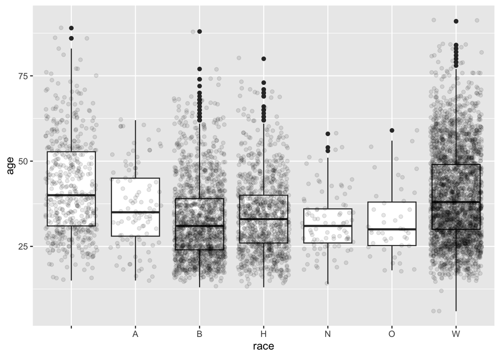

```r
df |> ggplot(aes(race,age)) +
  geom_boxplot() +
  geom_jitter(alpha=0.1)
```

```r
df |> count(armed) |> arrange(desc(n))
```

```
                              armed    n
1                               gun 3699
2                             knife  936
3                           unarmed  413
4                        toy weapon  219
5                                    208
6                           vehicle  204
7                      undetermined  173
8                    unknown weapon   77
9                           machete   49
10                            Taser   31
11                               ax   24
12                            sword   23
13                    gun and knife   21
14                     baseball bat   20
```

[output cut: 85 more lines]

Is there a difference between threat levels if a body camera is turned on?

```r
tbl<-table(df$threat_level,df$body_camera)
chisq.test(tbl)
```

```
    Pearson's Chi-squared test

data:  tbl
X-squared = 10.081, df = 2, p-value = 0.00647
```

## Sleep in mammals

```r
load("mammals.rda")
ls()
```

```
[1] "df"                     "fatal_police_shootings" "m"
[4] "mammals"                "tbl"                    "uniqdashc"
[7] "wideScreen"             "x"
```

```r
str(mammals)
```

```
tibble [62 × 11] (S3: tbl_df/tbl/data.frame)
 $ species     : Factor w/ 62 levels "Africanelephant",..: 1 2 3 4 5 6 7 8 9 10 ...
 $ body_wt     : num [1:62] 6654 1 3.38 0.92 2547 ...
 $ brain_wt    : num [1:62] 5712 6.6 44.5 5.7 4603 ...
 $ non_dreaming: num [1:62] NA 6.3 NA NA 2.1 9.1 15.8 5.2 10.9 8.3 ...
 $ dreaming    : num [1:62] NA 2 NA NA 1.8 0.7 3.9 1 3.6 1.4 ...
 $ total_sleep : num [1:62] 3.3 8.3 12.5 16.5 3.9 9.8 19.7 6.2 14.5 9.7 ...
 $ life_span   : num [1:62] 38.6 4.5 14 NA 69 27 19 30.4 28 50 ...
 $ gestation   : num [1:62] 645 42 60 25 624 180 35 392 63 230 ...
 $ predation   : int [1:62] 3 3 1 5 3 4 1 4 1 1 ...
 $ exposure    : int [1:62] 5 1 1 2 5 4 1 5 2 1 ...
 $ danger      : int [1:62] 3 3 1 3 4 4 1 4 1 1 ...
```

```r
df <- mammals
m <- lm(total_sleep ~ brain_wt,data=df)
summary(m)
```

```
Call:
lm(formula = total_sleep ~ brain_wt, data = df)

Residuals:
   Min     1Q Median     3Q    Max
-8.248 -2.610 -0.309  2.189  8.884

Coefficients:
              Estimate Std. Error t value Pr(>|t|)
(Intercept) 11.0163240  0.5941893   18.54  < 2e-16 ***
brain_wt    -0.0017195  0.0005991   -2.87  0.00578 **
---
Signif. codes:  0 '***' 0.001 '**' 0.01 '*' 0.05 '.' 0.1 ' ' 1

Residual standard error: 4.339 on 56 degrees of freedom
  (4 observations deleted due to missingness)
Multiple R-squared:  0.1282,    Adjusted R-squared:  0.1127
F-statistic: 8.238 on 1 and 56 DF,  p-value: 0.00578
```

```r
df |> select(total_sleep,species) |> arrange(total_sleep) |> print(n=62)
```

```
# A tibble: 62 × 2
   total_sleep species
         <dbl> <fct>
 1         2.6 Roedeer
 2         2.9 Horse
 3         3.1 Donkey
 4         3.3 Africanelephant
 5         3.8 Goat
 6         3.8 Sheep
 7         3.9 Asianelephant
 8         3.9 Cow
 9         5.4 Rockhyrax(Procaviahab)
10         5.4 Treehyrax
11         6.1 Genet
12         6.2 Braziliantapir
```

[output cut: 50 more lines]

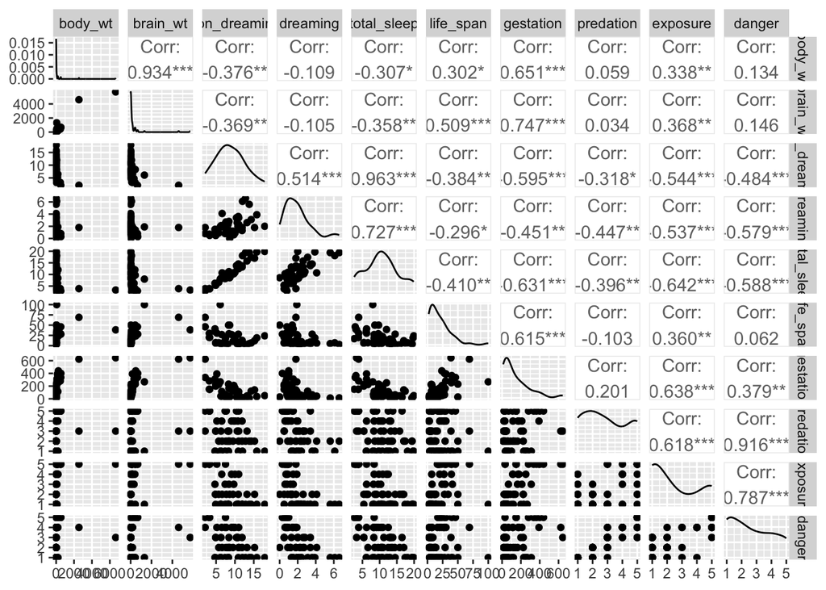

```r
pacman::p_load(GGally)
df |> select(-species) |> ggpairs()
```

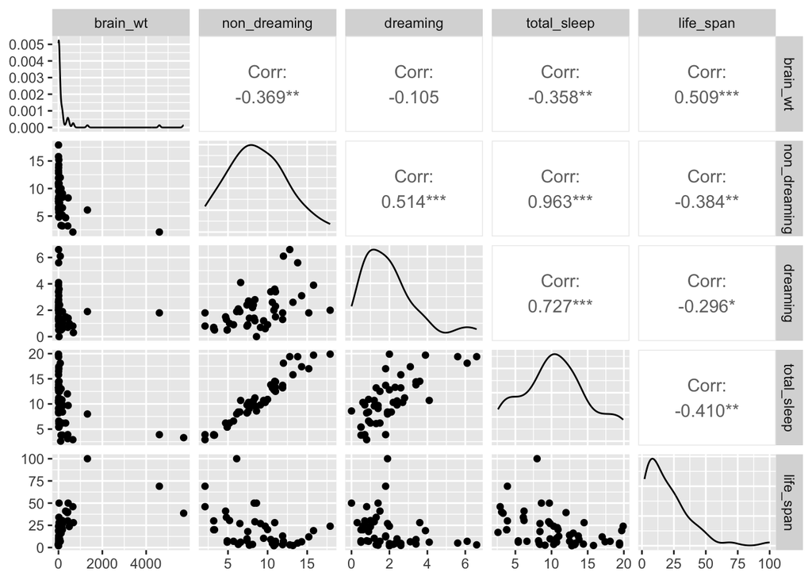

```r
df |> select(-species,-gestation,-exposure,-danger,-body_wt,-predation) |> ggpairs()
```

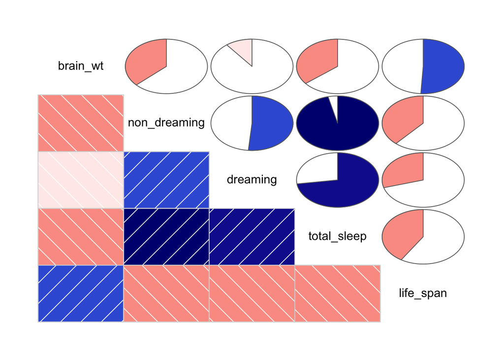

```r
pacman::p_load(corrgram)
df |> select(-species,-gestation,-exposure,-danger,-body_wt,-predation) |> corrgram(upper.panel=panel.pie)
```

There are loads of other options for scatterplot matrices, known in the R Graph Gallery as [correlograms](https://r-graph-gallery.com/correlogram.html).

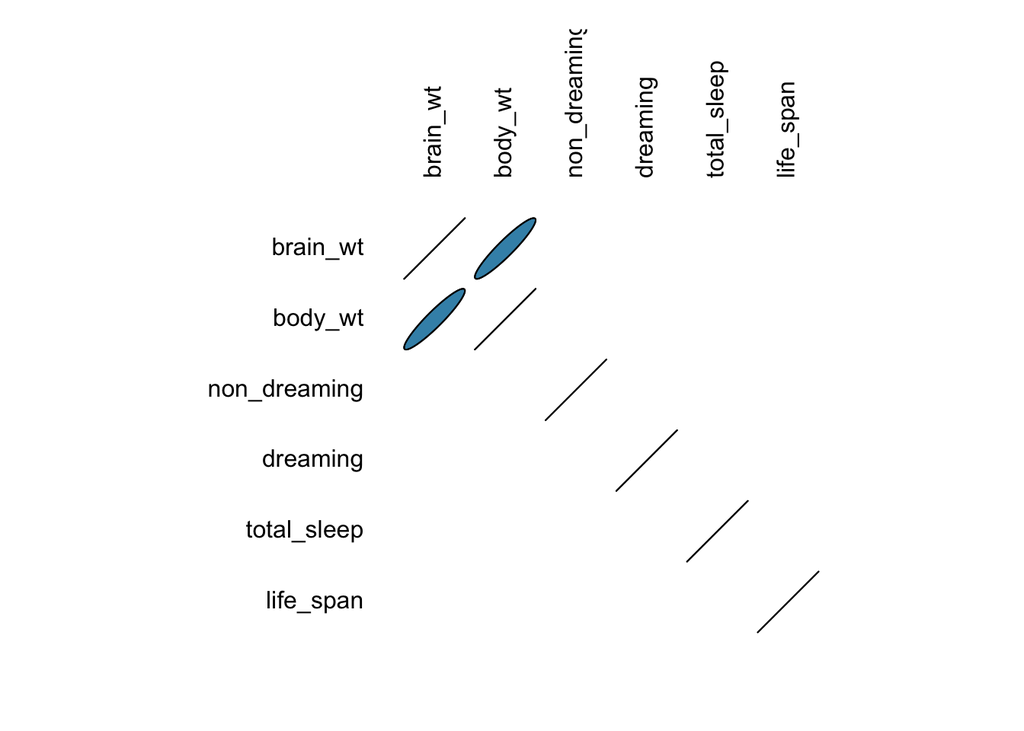

```r
pacman::p_load(ellipse)
pacman::p_load(RColorBrewer)
data <- cor(df[,2:7])
my_colors <- brewer.pal(5,"Spectral")
my_colors <- colorRampPalette(my_colors)(100)
ord <- order(data[1,])
data_ord <- data[ord,ord]
plotcorr(data_ord, col=my_colors[data_ord*50+50], mar=c(1,1,1,1) )
```

This didn’t work well, so my first guess is that I misspelled something. To check that, I’ll use the above code to reproduce the example in the R Graph Gallery.

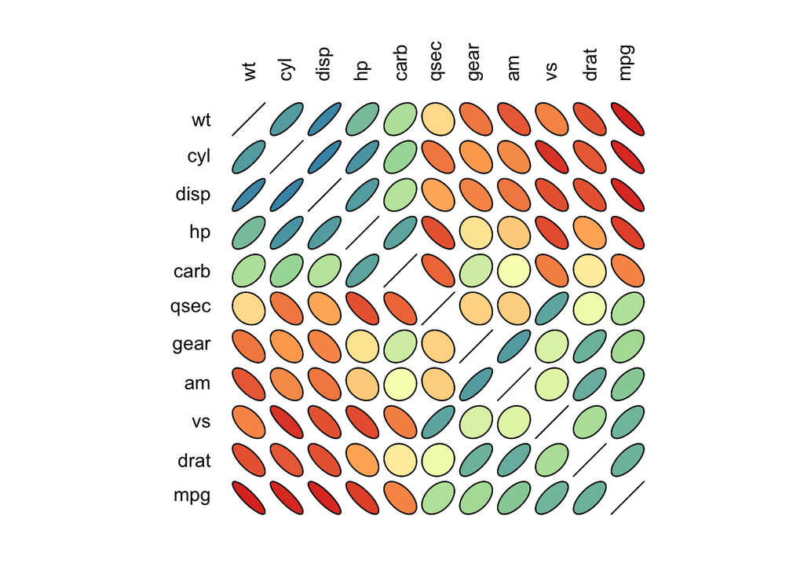

```r
data <- cor(mtcars)
my_colors <- brewer.pal(5,"Spectral")
my_colors <- colorRampPalette(my_colors)(100)
ord <- order(data[1,])
data_ord <- data[ord,ord]
plotcorr(data_ord, col=my_colors[data_ord*50+50], mar=c(1,1,1,1) )
```

This plots correctly, so there must be something else wrong. The next step is to find out what `ord` and `data_ord` are.

```r
ord
```

```
 [1]  6  2  3  4 11  7 10  9  8  5  1
```

```r
data_ord
```

```
             wt        cyl       disp         hp        carb        qsec
wt    1.0000000  0.7824958  0.8879799  0.6587479  0.42760594 -0.17471588
cyl   0.7824958  1.0000000  0.9020329  0.8324475  0.52698829 -0.59124207
disp  0.8879799  0.9020329  1.0000000  0.7909486  0.39497686 -0.43369788
hp    0.6587479  0.8324475  0.7909486  1.0000000  0.74981247 -0.70822339
carb  0.4276059  0.5269883  0.3949769  0.7498125  1.00000000 -0.65624923
qsec -0.1747159 -0.5912421 -0.4336979 -0.7082234 -0.65624923  1.00000000
gear -0.5832870 -0.4926866 -0.5555692 -0.1257043  0.27407284 -0.21268223
am   -0.6924953 -0.5226070 -0.5912270 -0.2432043  0.05753435 -0.22986086
vs   -0.5549157 -0.8108118 -0.7104159 -0.7230967 -0.56960714  0.74453544
drat -0.7124406 -0.6999381 -0.7102139 -0.4487591 -0.09078980  0.09120476
mpg  -0.8676594 -0.8521620 -0.8475514 -0.7761684 -0.55092507  0.41868403
           gear          am         vs        drat        mpg
wt   -0.5832870 -0.69249526 -0.5549157 -0.71244065 -0.8676594
cyl  -0.4926866 -0.52260705 -0.8108118 -0.69993811 -0.8521620
disp -0.5555692 -0.59122704 -0.7104159 -0.71021393 -0.8475514
hp   -0.1257043 -0.24320426 -0.7230967 -0.44875912 -0.7761684
carb  0.2740728  0.05753435 -0.5696071 -0.09078980 -0.5509251
qsec -0.2126822 -0.22986086  0.7445354  0.09120476  0.4186840
gear  1.0000000  0.79405876  0.2060233  0.69961013  0.4802848
am    0.7940588  1.00000000  0.1683451  0.71271113  0.5998324
vs    0.2060233  0.16834512  1.0000000  0.44027846  0.6640389
drat  0.6996101  0.71271113  0.4402785  1.00000000  0.6811719
mpg   0.4802848  0.59983243  0.6640389  0.68117191  1.0000000
```

Now I see the problem! Everything but but `brain_wt` and `body_wt` has NA values (three such values, I think).

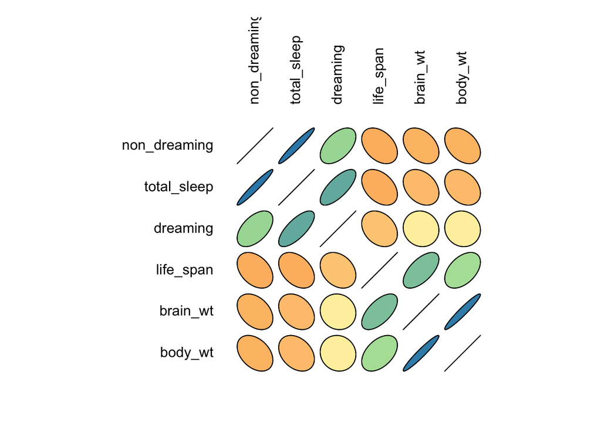

```r
# help(cor)
data <- cor(df[,2:7],use="complete.obs")
my_colors <- brewer.pal(5,"Spectral")
my_colors <- colorRampPalette(my_colors)(100)
ord <- order(data[1,])
data_ord <- data[ord,ord]
plotcorr(data_ord, col=my_colors[data_ord*50+50], mar=c(1,1,1,1) )
```

## Employment Resumes

```r
load("resume.rda")
ls()
```

```
 [1] "data"                   "data_ord"               "df"
 [4] "fatal_police_shootings" "m"                      "mammals"
 [7] "my_colors"              "ord"                    "resume"
[10] "tbl"                    "uniqdashc"              "wideScreen"
[13] "x"
```

```r
str(resume)
```

```
tibble [4,870 × 30] (S3: tbl_df/tbl/data.frame)
 $ job_ad_id             : num [1:4870] 384 384 384 384 385 386 386 385 386 386 ...
 $ job_city              : chr [1:4870] "Chicago" "Chicago" "Chicago" "Chicago" ...
 $ job_industry          : chr [1:4870] "manufacturing" "manufacturing" "manufacturing" "manufacturing" ...
 $ job_type              : chr [1:4870] "supervisor" "supervisor" "supervisor" "supervisor" ...
 $ job_fed_contractor    : num [1:4870] NA NA NA NA 0 0 0 0 0 0 ...
 $ job_equal_opp_employer: num [1:4870] 1 1 1 1 1 1 1 1 1 1 ...
 $ job_ownership         : chr [1:4870] "unknown" "unknown" "unknown" "unknown" ...
 $ job_req_any           : num [1:4870] 1 1 1 1 1 0 0 1 0 0 ...
 $ job_req_communication : num [1:4870] 0 0 0 0 0 0 0 0 0 0 ...
 $ job_req_education     : num [1:4870] 0 0 0 0 0 0 0 0 0 0 ...
 $ job_req_min_experience: chr [1:4870] "5" "5" "5" "5" ...
 $ job_req_computer      : num [1:4870] 1 1 1 1 1 0 0 1 0 0 ...
 $ job_req_organization  : num [1:4870] 0 0 0 0 1 0 0 1 0 0 ...
 $ job_req_school        : chr [1:4870] "none_listed" "none_listed" "none_listed" "none_listed" ...
```

[output cut: 16 more lines]

```r
df <- resume
m <- glm(received_callback ~ .,data=df,family="binomial")
summary(m)
```

```
Call:
glm(formula = received_callback ~ ., family = "binomial", data = df)

Coefficients: (3 not defined because of singularities)
                                            Estimate Std. Error z value
(Intercept)                               -4.372e+00  1.086e+00  -4.027
job_ad_id                                  9.499e-04  2.730e-04   3.480
job_cityChicago                           -7.525e-01  2.107e-01  -3.571
job_industryfinance_insurance_real_estate -4.924e-01  3.085e-01  -1.596
job_industrymanufacturing                 -3.764e-01  2.766e-01  -1.361
job_industryother_service                  2.720e-01  2.333e-01   1.166
job_industrytransportation_communication   1.790e-01  3.649e-01   0.490
job_industrywholesale_and_retail_trade    -1.188e-01  2.093e-01  -0.568
job_typemanager                            1.252e-01  3.308e-01   0.378
job_typeretail_sales                       1.692e-01  3.174e-01   0.533
job_typesales_rep                         -1.520e-01  3.474e-01  -0.437
job_typesecretary                         -1.089e-01  2.410e-01  -0.452
job_typesupervisor                         7.871e-02  3.423e-01   0.230
job_fed_contractor                         2.088e-01  2.356e-01   0.886
job_equal_opp_employer                     4.899e-01  1.655e-01   2.961
job_ownershipprivate                       8.911e-01  3.338e-01   2.669
job_ownershippublic                        7.876e-01  3.840e-01   2.051
job_ownershipunknown                       6.311e-01  3.762e-01   1.678
job_req_any                               -1.968e-01  2.542e-01  -0.774
job_req_communication                      4.130e-01  2.282e-01   1.810
job_req_education                         -2.205e-01  3.628e-01  -0.608
job_req_min_experience0                   -1.384e+01  1.189e+03  -0.012
job_req_min_experience0.5                  9.802e-01  1.191e+00   0.823
job_req_min_experience1                   -4.522e-02  4.103e-01  -0.110
job_req_min_experience10                   1.916e-01  1.087e+00   0.176
job_req_min_experience2                    1.477e-01  2.854e-01   0.517
job_req_min_experience3                   -5.928e-01  3.561e-01  -1.665
job_req_min_experience4                    3.798e-01  1.122e+00   0.338
job_req_min_experience5                   -4.773e-01  4.712e-01  -1.013
job_req_min_experience6                   -1.420e+01  1.144e+03  -0.012
job_req_min_experience7                   -1.366e+01  6.685e+02  -0.020
job_req_min_experience8                   -1.428e+01  8.151e+02  -0.018
job_req_min_experiencesome                -4.597e-02  2.186e-01  -0.210
job_req_computer                           1.815e-01  2.164e-01   0.839
job_req_organization                      -1.046e+00  4.596e-01  -2.275
```

[output cut: 136 more lines]

```
military                                  0.976143
employment_holes                          0.084553 .
has_email_address                         0.928739
resume_qualitylow                         0.107454
---
Signif. codes:  0 '***' 0.001 '**' 0.01 '*' 0.05 '.' 0.1 ' ' 1

(Dispersion parameter for binomial family taken to be 1)

    Null deviance: 1674.4  on 3101  degrees of freedom
Residual deviance: 1487.3  on 3018  degrees of freedom
  (1768 observations deleted due to missingness)
AIC: 1655.3

Number of Fisher Scoring iterations: 15
```

```r
m <- glm(received_callback ~ race,data=df,family="binomial")
summary(m)
```

```
Call:
glm(formula = received_callback ~ race, family = "binomial",
    data = df)

Coefficients:
            Estimate Std. Error z value Pr(>|z|)
(Intercept) -2.67481    0.08251 -32.417  < 2e-16 ***
racewhite    0.43818    0.10732   4.083 4.45e-05 ***
---
Signif. codes:  0 '***' 0.001 '**' 0.01 '*' 0.05 '.' 0.1 ' ' 1

(Dispersion parameter for binomial family taken to be 1)

    Null deviance: 2726.9  on 4869  degrees of freedom
Residual deviance: 2709.9  on 4868  degrees of freedom
AIC: 2713.9

Number of Fisher Scoring iterations: 5
```

```r
m <- glm(received_callback ~ gender,data=df,family="binomial")
summary(m)
```

```
Call:
glm(formula = received_callback ~ gender, family = "binomial",
    data = df)

Coefficients:
            Estimate Std. Error z value Pr(>|z|)
(Intercept) -2.40901    0.05939 -40.562   <2e-16 ***
genderm     -0.12008    0.12859  -0.934     0.35
---
Signif. codes:  0 '***' 0.001 '**' 0.01 '*' 0.05 '.' 0.1 ' ' 1

(Dispersion parameter for binomial family taken to be 1)

    Null deviance: 2726.9  on 4869  degrees of freedom
Residual deviance: 2726.0  on 4868  degrees of freedom
AIC: 2730

Number of Fisher Scoring iterations: 5
```

```r
(tbl <- table(df$gender,df$race))
```

```
    black white
  f  1886  1860
  m   549   575
```

```r
chisq.test(tbl)
```

```
    Pearson's Chi-squared test with Yates' continuity correction

data:  tbl
X-squared = 0.72289, df = 1, p-value = 0.3952
```

```r
(tbl <- table(df$received_callback,df$race))
```

```
    black white
  0  2278  2200
  1   157   235
```

```r
chisq.test(tbl)
```

```
    Pearson's Chi-squared test with Yates' continuity correction

data:  tbl
X-squared = 16.449, df = 1, p-value = 4.998e-05
```

## Sleep Deprivation

```r
load("sleep_deprivation.rda")
ls()
```

```
 [1] "data"                   "data_ord"               "df"
 [4] "fatal_police_shootings" "m"                      "mammals"
 [7] "my_colors"              "ord"                    "resume"
[10] "sleep_deprivation"      "tbl"                    "uniqdashc"
[13] "wideScreen"             "x"
```

```r
str(sleep_deprivation)
```

```
tibble [1,087 × 2] (S3: tbl_df/tbl/data.frame)
 $ sleep     : Factor w/ 3 levels "<6",">8","6-8": 1 1 1 1 1 1 1 1 1 1 ...
 $ profession: Factor w/ 5 levels "bus / taxi / limo drivers",..: 2 2 2 2 2 2 2 2 2 2 ...
```

```r
df <- sleep_deprivation
table(df$sleep,df$profession)
```

```
      bus / taxi / limo drivers control pilots train operators truck drivers
  <6                         21      35     19              29            35
  >8                         58      64     51              32            51
  6-8                       131     193    132             119           117
```

```r
m <- glm(profession ~ sleep,data=df,family="binomial")
summary(m)
```

```
Call:
glm(formula = profession ~ sleep, family = "binomial", data = df)

Coefficients:
            Estimate Std. Error z value Pr(>|z|)
(Intercept)   1.7262     0.2368   7.288 3.14e-13 ***
sleep>8      -0.4983     0.2800  -1.780   0.0751 .
sleep6-8     -0.2716     0.2559  -1.061   0.2886
---
Signif. codes:  0 '***' 0.001 '**' 0.01 '*' 0.05 '.' 0.1 ' ' 1

(Dispersion parameter for binomial family taken to be 1)

    Null deviance: 1067.0  on 1086  degrees of freedom
Residual deviance: 1063.5  on 1084  degrees of freedom
AIC: 1069.5

Number of Fisher Scoring iterations: 4
```

```r
m <- glm(sleep ~ profession,data=df,family="binomial")
summary(m)
```

```
Call:
glm(formula = sleep ~ profession, family = "binomial", data = df)

Coefficients:
                          Estimate Std. Error z value Pr(>|z|)
(Intercept)                2.19722    0.23000   9.553   <2e-16 ***
professioncontrol         -0.20350    0.29217  -0.697   0.4861
professionpilots           0.06782    0.33314   0.204   0.8387
professiontrain operators -0.54724    0.30660  -1.785   0.0743 .
professiontruck drivers   -0.62861    0.29568  -2.126   0.0335 *
---
Signif. codes:  0 '***' 0.001 '**' 0.01 '*' 0.05 '.' 0.1 ' ' 1

(Dispersion parameter for binomial family taken to be 1)

    Null deviance: 831.18  on 1086  degrees of freedom
Residual deviance: 822.22  on 1082  degrees of freedom
AIC: 832.22

Number of Fisher Scoring iterations: 4
```

```r
df$sleep <- ordered(df$sleep, levels = c("<6","6-8",">8"))
m <- glm(sleep ~ profession,data=df,family="binomial")
summary(m)
```

```
Call:
glm(formula = sleep ~ profession, family = "binomial", data = df)

Coefficients:
                          Estimate Std. Error z value Pr(>|z|)
(Intercept)                2.19722    0.23000   9.553   <2e-16 ***
professioncontrol         -0.20350    0.29217  -0.697   0.4861
professionpilots           0.06782    0.33314   0.204   0.8387
professiontrain operators -0.54724    0.30660  -1.785   0.0743 .
professiontruck drivers   -0.62861    0.29568  -2.126   0.0335 *
---
Signif. codes:  0 '***' 0.001 '**' 0.01 '*' 0.05 '.' 0.1 ' ' 1

(Dispersion parameter for binomial family taken to be 1)

    Null deviance: 831.18  on 1086  degrees of freedom
Residual deviance: 822.22  on 1082  degrees of freedom
AIC: 832.22

Number of Fisher Scoring iterations: 4
```

```r
m <- glm(profession ~ sleep,data=df,family="binomial")
summary(m)
```

```
Call:
glm(formula = profession ~ sleep, family = "binomial", data = df)

Coefficients:
            Estimate Std. Error z value Pr(>|z|)
(Intercept)  1.46950    0.09877  14.878   <2e-16 ***
sleep.L     -0.35238    0.19797  -1.780   0.0751 .
sleep.Q      0.01835    0.13907   0.132   0.8950
---
Signif. codes:  0 '***' 0.001 '**' 0.01 '*' 0.05 '.' 0.1 ' ' 1

(Dispersion parameter for binomial family taken to be 1)

    Null deviance: 1067.0  on 1086  degrees of freedom
Residual deviance: 1063.5  on 1084  degrees of freedom
AIC: 1069.5

Number of Fisher Scoring iterations: 4
```

Oops! It is only by coincidence that we get an output for each of these models. The `glm()` function is not applicable to multinomial models unless we do a lot of math on it. Even then, it’s not universally applicable. Much better is to actually construct a multinomial logistic regression model. We did that last time with the `multinom()` function, but the output was hard to interpret. Let’s use the `tidy()` function to make it easier to read.

```r
pacman::p_load(nnet)
pacman::p_load(broom)
pacman::p_load(kableExtra)
m <- multinom(sleep ~ profession,data=df)
tidy(m, conf.int = TRUE) |> kable() |> kable_styling("basic",full_width=FALSE)
```

| y.level | term | estimate | std.error | statistic | p.value | conf.low | conf.high |
| --- | --- | --- | --- | --- | --- | --- | --- |
| 6-8 | (Intercept) | 1.8306335 | 0.2350556 | 7.7880880 | 0.0000000 | 1.3699331 | 2.2913340 |
| 6-8 | professioncontrol | -0.1233365 | 0.2983337 | -0.4134181 | 0.6793003 | -0.7080598 | 0.4613867 |
| 6-8 | professionpilots | 0.1076454 | 0.3397862 | 0.3168033 | 0.7513929 | -0.5583234 | 0.7736142 |
| 6-8 | professiontrain operators | -0.4188257 | 0.3132678 | -1.3369574 | 0.1812366 | -1.0328192 | 0.1951679 |
| 6-8 | professiontruck drivers | -0.6238287 | 0.3039230 | -2.0525879 | 0.0401126 | -1.2195069 | -0.0281505 |
| >8 | (Intercept) | 1.0158943 | 0.2546738 | 3.9890023 | 0.0000664 | 0.5167429 | 1.5150458 |
| >8 | professioncontrol | -0.4123800 | 0.3302332 | -1.2487539 | 0.2117551 | -1.0596252 | 0.2348652 |
| >8 | professionpilots | -0.0285802 | 0.3702625 | -0.0771890 | 0.9384732 | -0.7542813 | 0.6971209 |
| >8 | professiontrain operators | -0.9174745 | 0.3613738 | -2.5388517 | 0.0111217 | -1.6257542 | -0.2091949 |
| >8 | professiontruck drivers | -0.6394257 | 0.3362105 | -1.9018613 | 0.0571893 | -1.2983862 | 0.0195347 |

The `kable` stuff is because, by default, the tibble output format of `tidy()` only shows the first ten letters of a `chr` column, which is not enough to distinguish between them, given that they are all prefixed with the word “profession.” The `kableExtra` package provides the tools to construct a better-looking html table.

```r
df$sleep <- ordered(df$sleep, levels = c(">8","6-8","<6"))
m <- multinom(sleep ~ profession,data=df)
tidy(m, conf.int = TRUE) |> kable() |> kable_styling("basic",full_width=FALSE)
```

| y.level | term | estimate | std.error | statistic | p.value | conf.low | conf.high |
| --- | --- | --- | --- | --- | --- | --- | --- |
| 6-8 | (Intercept) | 0.8147439 | 0.1577176 | 5.1658408 | 0.0000002 | 0.5056231 | 1.1238646 |
| 6-8 | professioncontrol | 0.2890608 | 0.2137315 | 1.3524486 | 0.1762318 | -0.1298451 | 0.7079668 |
| 6-8 | professionpilots | 0.1362254 | 0.2281630 | 0.5970531 | 0.5504719 | -0.3109658 | 0.5834166 |
| 6-8 | professiontrain operators | 0.4986388 | 0.2540238 | 1.9629612 | 0.0496507 | 0.0007614 | 0.9965162 |
| 6-8 | professiontruck drivers | 0.0156043 | 0.2302817 | 0.0677617 | 0.9459753 | -0.4357396 | 0.4669481 |
| <6 | (Intercept) | -1.0159415 | 0.2546780 | -3.9891222 | 0.0000663 | -1.5151012 | -0.5167819 |
| <6 | professioncontrol | 0.4123970 | 0.3302385 | 1.2487853 | 0.2117436 | -0.2348586 | 1.0596525 |
| <6 | professionpilots | 0.0285458 | 0.3702707 | 0.0770943 | 0.9385485 | -0.6971714 | 0.7542630 |
| <6 | professiontrain operators | 0.9174965 | 0.3613773 | 2.5388883 | 0.0111205 | 0.2092101 | 1.6257829 |
| <6 | professiontruck drivers | 0.6394607 | 0.3362145 | 1.9019426 | 0.0571787 | -0.0195076 | 1.2984290 |

## Murders (not recommended for analysis)

```r
load("murders.rda")
ls()
```

```
 [1] "data"                   "data_ord"               "df"
 [4] "fatal_police_shootings" "m"                      "mammals"
 [7] "murders"                "my_colors"              "ord"
[10] "resume"                 "sleep_deprivation"      "tbl"
[13] "uniqdashc"              "wideScreen"             "x"
```

```r
str(murders)
```

```
tibble [20 × 4] (S3: tbl_df/tbl/data.frame)
 $ population            : int [1:20] 587000 643000 635000 692000 1248000 643000 1964000 1531000 713000 749000 ...
 $ perc_pov              : num [1:20] 16.5 20.5 26.3 16.5 19.2 16.5 20.2 21.3 17.2 14.3 ...
 $ perc_unemp            : num [1:20] 6.2 6.4 9.3 5.3 7.3 5.9 6.4 7.6 4.9 6.4 ...
 $ annual_murders_per_mil: num [1:20] 11.2 13.4 40.7 5.3 24.8 12.7 20.9 35.7 8.7 9.6 ...
```

```r
df <- murders
m <- lm(annual_murders_per_mil ~ .,data=df)
summary(m)
```

```
Call:
lm(formula = annual_murders_per_mil ~ ., data = df)

Residuals:
    Min      1Q  Median      3Q     Max
-5.7174 -3.3233  0.4031  1.7684 10.0329

Coefficients:
              Estimate Std. Error t value Pr(>|t|)
(Intercept) -3.676e+01  7.011e+00  -5.244 8.03e-05 ***
population   7.629e-07  6.363e-07   1.199  0.24798
perc_pov     1.192e+00  5.617e-01   2.123  0.04974 *
perc_unemp   4.720e+00  1.530e+00   3.084  0.00712 **
---
Signif. codes:  0 '***' 0.001 '**' 0.01 '*' 0.05 '.' 0.1 ' ' 1

Residual standard error: 4.59 on 16 degrees of freedom
Multiple R-squared:  0.8183,    Adjusted R-squared:  0.7843
F-statistic: 24.02 on 3 and 16 DF,  p-value: 3.629e-06
```

When people are unemployed, their thoughts turn to murder. Wait, wut?

## NBA players 2018–2019

```r
load("nba_players_19.rda")
ls()
```

```
 [1] "data"                   "data_ord"               "df"
 [4] "fatal_police_shootings" "m"                      "mammals"
 [7] "murders"                "my_colors"              "nba_players_19"
[10] "ord"                    "resume"                 "sleep_deprivation"
[13] "tbl"                    "uniqdashc"              "wideScreen"
[16] "x"
```

```r
str(nba_players_19)
```

```
tibble [494 × 7] (S3: tbl_df/tbl/data.frame)
 $ first_name: chr [1:494] "Alex" "Jaylen" "Steven" "Bam" ...
 $ last_name : chr [1:494] "Abrines" "Adams" "Adams" "Adebayo" ...
 $ team      : chr [1:494] "Thunder" "Hawks" "Thunder" "Heat" ...
 $ team_abbr : chr [1:494] "OKC" "ATL" "OKC" "MIA" ...
 $ position  : chr [1:494] "Guard" "Guard" "Center" "Center-Forward" ...
 $ number    : chr [1:494] "8" "10" "12" "13" ...
 $ height    : num [1:494] 78 74 84 82 78 83 77 77 83 81 ...
```

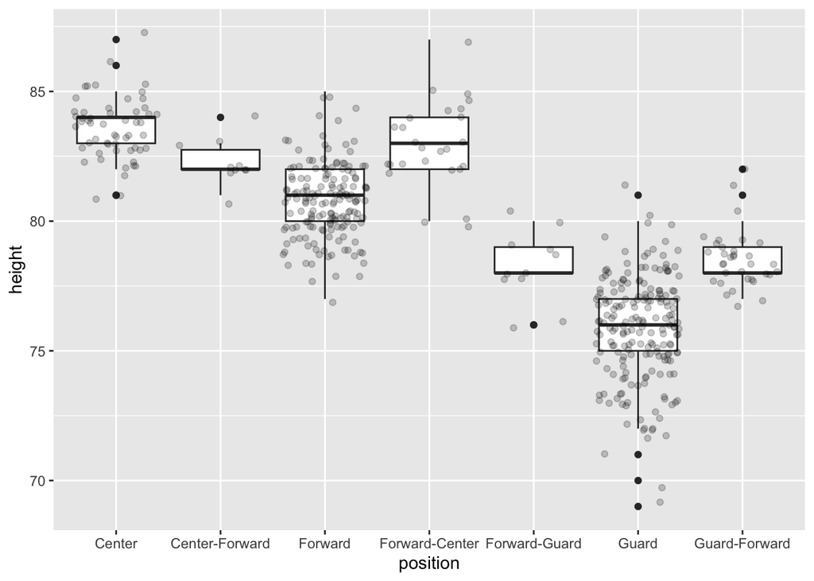

```r
df <- nba_players_19
df |> ggplot(aes(position,height)) +
  geom_boxplot() +
  geom_jitter(alpha=0.2)
```

## Poker (anonymous)

```r
load("poker.rda")
ls()
```

```
 [1] "data"                   "data_ord"               "df"
 [4] "fatal_police_shootings" "m"                      "mammals"
 [7] "murders"                "my_colors"              "nba_players_19"
[10] "ord"                    "poker"                  "resume"
[13] "sleep_deprivation"      "tbl"                    "uniqdashc"
[16] "wideScreen"             "x"
```

```r
str(poker)
```

```
tibble [50 × 1] (S3: tbl_df/tbl/data.frame)
 $ winnings: int [1:50] -110 -9 -60 316 -200 -196 320 -160 31 331 ...
```

```r
df <- poker
stem(df$winnings)
```

```
  The decimal point is 3 digit(s) to the right of the |

  -1 | 00
  -0 | 9875
  -0 | 333222221111100000
   0 | 000001111112233333444
   0 | 889
   1 |
   1 | 7
   2 |
   2 |
   3 |
   3 | 7
```

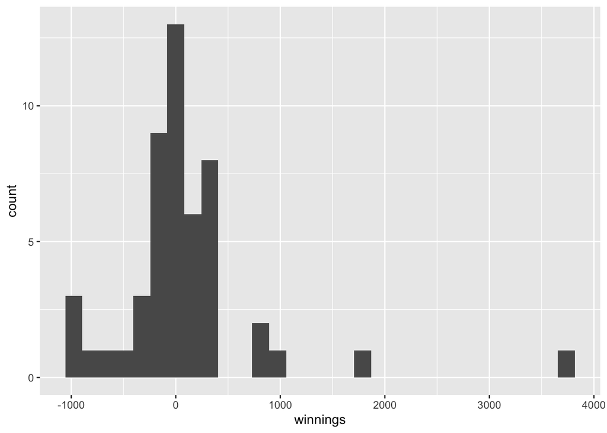

```r
df |> ggplot(aes(winnings)) +
  geom_histogram()
```

## SAT and GPA data

```r
load("satgpa.rda")
ls()
```

```
 [1] "data"                   "data_ord"               "df"
 [4] "fatal_police_shootings" "m"                      "mammals"
 [7] "murders"                "my_colors"              "nba_players_19"
[10] "ord"                    "poker"                  "resume"
[13] "satgpa"                 "sleep_deprivation"      "tbl"
[16] "uniqdashc"              "wideScreen"             "x"
```

```r
str(satgpa)
```

```
tibble [1,000 × 6] (S3: tbl_df/tbl/data.frame)
 $ sex    : int [1:1000] 1 2 2 1 1 2 1 1 2 1 ...
 $ sat_v  : int [1:1000] 65 58 56 42 55 55 57 53 67 41 ...
 $ sat_m  : int [1:1000] 62 64 60 53 52 56 65 62 77 44 ...
 $ sat_sum: int [1:1000] 127 122 116 95 107 111 122 115 144 85 ...
 $ hs_gpa : num [1:1000] 3.4 4 3.75 3.75 4 4 2.8 3.8 4 2.6 ...
 $ fy_gpa : num [1:1000] 3.18 3.33 3.25 2.42 2.63 2.91 2.83 2.51 3.82 2.54 ...
```

```r
df <- satgpa
# m <- glm(sex ~ .,data=df,family="binomial")
table(df$sex)
```

```
  1   2
516 484
```

```r
df$sex <- ifelse(df$sex == 2,0,1)
m <- glm(sex ~ .,data=df,family="binomial")
summary(m)
```

```
Call:
glm(formula = sex ~ ., family = "binomial", data = df)

Coefficients: (1 not defined because of singularities)
             Estimate Std. Error z value Pr(>|z|)
(Intercept) -1.600177   0.553805  -2.889 0.003859 **
sat_v       -0.004676   0.009844  -0.475 0.634824
sat_m        0.107299   0.010710  10.019  < 2e-16 ***
sat_sum            NA         NA      NA       NA
hs_gpa      -0.920906   0.161527  -5.701 1.19e-08 ***
fy_gpa      -0.400117   0.117156  -3.415 0.000637 ***
---
Signif. codes:  0 '***' 0.001 '**' 0.01 '*' 0.05 '.' 0.1 ' ' 1

(Dispersion parameter for binomial family taken to be 1)

    Null deviance: 1385.3  on 999  degrees of freedom
Residual deviance: 1233.7  on 995  degrees of freedom
AIC: 1243.7

Number of Fisher Scoring iterations: 4
```

Who knows which sex is which? Anyway.

```r
m <- lm(sat_m ~ hs_gpa,data=df)
summary(m)
```

```
Call:
lm(formula = sat_m ~ hs_gpa, data = df)

Residuals:
     Min       1Q   Median       3Q      Max
-25.0738  -5.2266   0.2412   5.0743  22.7225

Coefficients:
            Estimate Std. Error t value Pr(>|t|)
(Intercept)  35.5320     1.4829   23.96   <2e-16 ***
hs_gpa        5.8982     0.4572   12.90   <2e-16 ***
---
Signif. codes:  0 '***' 0.001 '**' 0.01 '*' 0.05 '.' 0.1 ' ' 1

Residual standard error: 7.827 on 998 degrees of freedom
Multiple R-squared:  0.1429,    Adjusted R-squared:  0.1421
F-statistic: 166.4 on 1 and 998 DF,  p-value: < 2.2e-16
```

```r
m <- lm(fy_gpa ~ sat_m,data=df)
summary(m)
```

```
Call:
lm(formula = fy_gpa ~ sat_m, data = df)

Residuals:
     Min       1Q   Median       3Q      Max
-2.28486 -0.44666  0.00499  0.49423  1.68271

Coefficients:
            Estimate Std. Error t value Pr(>|t|)
(Intercept) 0.621899   0.140849   4.415 1.12e-05 ***
sat_m       0.033938   0.002559  13.264  < 2e-16 ***
---
Signif. codes:  0 '***' 0.001 '**' 0.01 '*' 0.05 '.' 0.1 ' ' 1

Residual standard error: 0.6834 on 998 degrees of freedom
Multiple R-squared:  0.1499,    Adjusted R-squared:  0.149
F-statistic: 175.9 on 1 and 998 DF,  p-value: < 2.2e-16
```